# Exploratory Data Analysis of Turkish Tourism Statistics

R U Mine

Last edited: Aralık 14, 2021 22:57

## *About Tourism Statistics Datasets*

The datasets is about Turkey’s tourism statistics. There are 3 different type of datasets including “Travel Incomes and Expenses”, “Distribution of Arriving Foreign Visitors According to Cities to Which Border Gates are Bound” and “Tourists by Nationalities”. In this project, these datasets will be analyzed between 2008-2021 years.

### *Tourists by Nationalities*

In this data set, the nationalities of the tourists who visited Turkey between January 2008 and September 2021 are shown.

```r
library(lubridate)
library(tidyverse)
library(readr)
library(MASS)
library(reshape2)
library(reshape)
library(eeptools)
library(dplyr)
library(scales)
library(rmarkdown)
library(viridis)
library(season)
library(gridExtra)
library(treemap)
library(treemapify)
library(hrbrthemes)
library(highcharter)
library(ggrepel)




tbn <- read_rds("https://raw.githubusercontent.com/pjournal/mef05g-r-u-mine/gh-pages/files/Tourists_by_nationalities2.rds")
tbn_dist <- read_rds("https://raw.githubusercontent.com/pjournal/mef05g-r-u-mine/gh-pages/files/tbn_dist.rds")

head(tbn)
```

|  | ï..Tarih | ALMANYA | ARNAVUTLUK | AVUSTURYA | BELCIKA | BOSNAHERSEK | BULGARISTAN | CEKCUMHURIYETI | DANIMARKA | ESTONYA | FINLANDIYA | FRANSA | GKIBRIS | HIRVATISTAN | HOLLANDA | INGILTERE | IRLANDA | ISPANYA | ISVEC | ISVICRE | ITALYA | IZLANDA | KARADAG | KOSOVA | LETONYA | LITVANYA | LUKSEMBURG | MACARISTAN | MAKEDONYA | … |
| --- | --- | --- | --- | --- | --- | --- | --- | --- | --- | --- | --- | --- | --- | --- | --- | --- | --- | --- | --- | --- | --- | --- | --- | --- | --- | --- | --- | --- | --- | --- |
| 1 | 2008/01 | 177,233 | 2,811 | 20,207 | 12,389 | 2,546 | 99,048 | 1,824 | 5,613 | 426 | 1,921 | 30,796 | 296 | 2,354 | 32,012 | 35,215 | 2,086 | 7,724 | 8,156 | 9,655 | 24,918 | 72 | 0 | 0 | 1,126 | 1,076 | 164 | 2,266 | 5,480 | … |
| 2 | 2008/02 | 143,666 | 2,604 | 16,295 | 11,309 | 2,342 | 82,707 | 2,064 | 5,464 | 515 | 1,723 | 29,228 | 369 | 1,738 | 23,565 | 33,385 | 1,723 | 8,331 | 5,808 | 8,947 | 15,204 | 99 | 0 | 0 | 1,309 | 1,198 | 155 | 2,281 | 5,253 | … |
| 3 | 2008/03 | 249,797 | 3,626 | 23,558 | 21,097 | 2,952 | 102,877 | 2,524 | 11,288 | 695 | 4,142 | 36,832 | 435 | 2,649 | 34,660 | 46,445 | 3,593 | 27,664 | 11,248 | 13,368 | 25,805 | 367 | 0 | 0 | 2,050 | 2,262 | 341 | 3,085 | 5,930 | … |
| 4 | 2008/04 | 242,531 | 3,219 | 22,668 | 30,772 | 3,539 | 110,627 | 4,198 | 10,878 | 1,098 | 7,661 | 73,221 | 527 | 2,384 | 47,950 | 85,841 | 3,846 | 20,599 | 14,843 | 14,681 | 34,936 | 622 | 0 | 0 | 2,251 | 3,400 | 394 | 3,974 | 7,985 | … |
| 5 | 2008/05 | 399,724 | 4,156 | 32,265 | 50,483 | 4,709 | 148,642 | 9,286 | 26,008 | 4,508 | 12,479 | 85,549 | 888 | 2,997 | 183,312 | 203,340 | 11,936 | 31,934 | 47,482 | 22,433 | 58,499 | 463 | 0 | 0 | 6,950 | 14,423 | 2,813 | 5,364 | 8,042 | … |
| 6 | 2008/06 | 364,145 | 4,862 | 44,762 | 54,415 | 6,093 | 142,896 | 22,824 | 29,591 | 4,649 | 12,565 | 76,481 | 898 | 2,500 | 99,473 | 289,104 | 17,955 | 31,267 | 53,109 | 18,824 | 72,876 | 2,065 | 0 | 0 | 7,551 | 15,560 | 606 | 10,138 | 8,830 | … |

```r
tbn1 <- tbn[, 1:2]
tbn1$ALMANYA <- NULL
tbn2 <- apply(tbn[,2:103], FUN = decomma, MARGIN = 2)
result = cbind(tbn1,tbn2)
```

We check the datatype and whether there is null values.

```r
str(result)
```

```
## 'data.frame':    165 obs. of  103 variables:
##  $ ï..Tarih      : chr  "2008/01" "2008/02" "2008/03" "2008/04" ...
##  $ ALMANYA       : num  177233 143666 249797 242531 399724 ...
##  $ ARNAVUTLUK    : num  2811 2604 3626 3219 4156 ...
##  $ AVUSTURYA     : num  20207 16295 23558 22668 32265 ...
##  $ BELCIKA       : num  12389 11309 21097 30772 50483 ...
##  $ BOSNAHERSEK   : num  2546 2342 2952 3539 4709 ...
##  $ BULGARISTAN   : num  99048 82707 102877 110627 148642 ...
##  $ CEKCUMHURIYETI: num  1824 2064 2524 4198 9286 ...
##  $ DANIMARKA     : num  5613 5464 11288 10878 26008 ...
##  $ ESTONYA       : num  426 515 695 1098 4508 ...
##  $ FINLANDIYA    : num  1921 1723 4142 7661 12479 ...
##  $ FRANSA        : num  30796 29228 36832 73221 85549 ...
##  $ GKIBRIS       : num  296 369 435 527 888 ...
##  $ HIRVATISTAN   : num  2354 1738 2649 2384 2997 ...
```

[output cut: 86 more lines]

```r
colSums(is.na(result))
```

```
##       ï..Tarih        ALMANYA     ARNAVUTLUK      AVUSTURYA        BELCIKA
##              0              0              0              0              0
##    BOSNAHERSEK    BULGARISTAN CEKCUMHURIYETI      DANIMARKA        ESTONYA
##              0              0              0              0              0
##     FINLANDIYA         FRANSA        GKIBRIS    HIRVATISTAN       HOLLANDA
##              0              0              0              0              0
##      INGILTERE        IRLANDA        ISPANYA          ISVEC        ISVICRE
##              0              0              0              0              0
##         ITALYA        IZLANDA        KARADAG         KOSOVA        LETONYA
##              0              0              0              0              0
##       LITVANYA     LUKSEMBURG     MACARISTAN      MAKEDONYA          MALTA
##              0              0              0              0              0
##         NORVEC        POLONYA       PORTEKIZ        ROMANYA      SIRBISTAN
##              0              0              0              0              0
##       SLOVAKYA       SLOVENYA     YUNANISTAN        DAVRUPA      AVRUPATOP
##              0              0              0              0              0
##     AZERBAYCAN        BELARUS     ERMENISTAN      GURCISTAN     KAZAKISTAN
##              0              0              0              0              0
##    KIRGIZISTAN     MOLDOVACUM     OZBEKISTAN          RUSYA     TACIKISTAN
##              0              0              0              0              0
##   TURKMENISTAN        UKRAYNA      BDTTOPLAM            ABD       ARJANTIN
##              0              0              0              0              0
##       BREZILYA         KANADA      KOLOMBIYA        MEKSIKA           SILI
##              0              0              0              0              0
##     VENEZUELLA       DAMERIKA     AMERIKATOP        CEZAYIR            FAS
##              0              0              0              0              0
##        GAFRIKA          LIBYA          MISIR          SUDAN          TUNUS
##              0              0              0              0              0
##        DAFRIKA      AFRIKATOP            BAE        BAHREYN      BANGLADES
##              0              0              0              0              0
##            CIN      ENDONEZYA     FILIPINLER          GKORE      HINDISTAN
##              0              0              0              0              0
##           IRAK           IRAN         ISRAIL        JAPONYA           KKTC
##              0              0              0              0              0
##          KATAR         KUVEYT         LUBNAN        MALEZYA       PAKISTAN
##              0              0              0              0              0
##       SINGAPUR         SURIYE  SUUDARABISTAN        TAYLAND          URDUN
##              0              0              0              0              0
##          YEMEN          DASYA        ASYATOP     AVUSTRALYA   YENIZELLANDA
##              0              0              0              0              0
##      OKYANUSYA     MILLIYESIZ        GTOPLAM
##              0              0              0
```

We change the date data type character to date time.

```r
result$ï..Tarih <- paste0(result$ï..Tarih,"/01")

str(result$ï..Tarih)
```

```
##  chr [1:165] "2008/01/01" "2008/02/01" "2008/03/01" "2008/04/01" ...
```

```r
result$ï..Tarih <- as.Date(result$ï..Tarih, format = "%Y/%m/%d")
str(result$ï..Tarih)
```

```
##  Date[1:165], format: "2008-01-01" "2008-02-01" "2008-03-01" "2008-04-01" "2008-05-01" ...
```

```r
str(result)
```

```
## 'data.frame':    165 obs. of  103 variables:
##  $ ï..Tarih      : Date, format: "2008-01-01" "2008-02-01" ...
##  $ ALMANYA       : num  177233 143666 249797 242531 399724 ...
##  $ ARNAVUTLUK    : num  2811 2604 3626 3219 4156 ...
##  $ AVUSTURYA     : num  20207 16295 23558 22668 32265 ...
##  $ BELCIKA       : num  12389 11309 21097 30772 50483 ...
##  $ BOSNAHERSEK   : num  2546 2342 2952 3539 4709 ...
##  $ BULGARISTAN   : num  99048 82707 102877 110627 148642 ...
##  $ CEKCUMHURIYETI: num  1824 2064 2524 4198 9286 ...
##  $ DANIMARKA     : num  5613 5464 11288 10878 26008 ...
##  $ ESTONYA       : num  426 515 695 1098 4508 ...
##  $ FINLANDIYA    : num  1921 1723 4142 7661 12479 ...
##  $ FRANSA        : num  30796 29228 36832 73221 85549 ...
##  $ GKIBRIS       : num  296 369 435 527 888 ...
##  $ HIRVATISTAN   : num  2354 1738 2649 2384 2997 ...
```

[output cut: 86 more lines]

We delete total columns that we do not use.

```r
tbn_d = subset(result, select = -c(AFRIKATOP,AMERIKATOP,BDTTOPLAM,ASYATOP,AVRUPATOP,GTOPLAM,OKYANUSYA))
str(tbn_d)
```

```
## 'data.frame':    165 obs. of  96 variables:
##  $ ï..Tarih      : Date, format: "2008-01-01" "2008-02-01" ...
##  $ ALMANYA       : num  177233 143666 249797 242531 399724 ...
##  $ ARNAVUTLUK    : num  2811 2604 3626 3219 4156 ...
##  $ AVUSTURYA     : num  20207 16295 23558 22668 32265 ...
##  $ BELCIKA       : num  12389 11309 21097 30772 50483 ...
##  $ BOSNAHERSEK   : num  2546 2342 2952 3539 4709 ...
##  $ BULGARISTAN   : num  99048 82707 102877 110627 148642 ...
##  $ CEKCUMHURIYETI: num  1824 2064 2524 4198 9286 ...
##  $ DANIMARKA     : num  5613 5464 11288 10878 26008 ...
##  $ ESTONYA       : num  426 515 695 1098 4508 ...
##  $ FINLANDIYA    : num  1921 1723 4142 7661 12479 ...
##  $ FRANSA        : num  30796 29228 36832 73221 85549 ...
##  $ GKIBRIS       : num  296 369 435 527 888 ...
##  $ HIRVATISTAN   : num  2354 1738 2649 2384 2997 ...
```

[output cut: 82 more lines]

```r
colSums(is.na(tbn_d))
```

```
##       ï..Tarih        ALMANYA     ARNAVUTLUK      AVUSTURYA        BELCIKA
##              0              0              0              0              0
##    BOSNAHERSEK    BULGARISTAN CEKCUMHURIYETI      DANIMARKA        ESTONYA
##              0              0              0              0              0
##     FINLANDIYA         FRANSA        GKIBRIS    HIRVATISTAN       HOLLANDA
##              0              0              0              0              0
##      INGILTERE        IRLANDA        ISPANYA          ISVEC        ISVICRE
##              0              0              0              0              0
##         ITALYA        IZLANDA        KARADAG         KOSOVA        LETONYA
##              0              0              0              0              0
##       LITVANYA     LUKSEMBURG     MACARISTAN      MAKEDONYA          MALTA
##              0              0              0              0              0
##         NORVEC        POLONYA       PORTEKIZ        ROMANYA      SIRBISTAN
##              0              0              0              0              0
##       SLOVAKYA       SLOVENYA     YUNANISTAN        DAVRUPA     AZERBAYCAN
##              0              0              0              0              0
##        BELARUS     ERMENISTAN      GURCISTAN     KAZAKISTAN    KIRGIZISTAN
##              0              0              0              0              0
##     MOLDOVACUM     OZBEKISTAN          RUSYA     TACIKISTAN   TURKMENISTAN
##              0              0              0              0              0
##        UKRAYNA            ABD       ARJANTIN       BREZILYA         KANADA
##              0              0              0              0              0
##      KOLOMBIYA        MEKSIKA           SILI     VENEZUELLA       DAMERIKA
##              0              0              0              0              0
##        CEZAYIR            FAS        GAFRIKA          LIBYA          MISIR
##              0              0              0              0              0
##          SUDAN          TUNUS        DAFRIKA            BAE        BAHREYN
##              0              0              0              0              0
##      BANGLADES            CIN      ENDONEZYA     FILIPINLER          GKORE
##              0              0              0              0              0
##      HINDISTAN           IRAK           IRAN         ISRAIL        JAPONYA
##              0              0              0              0              0
##           KKTC          KATAR         KUVEYT         LUBNAN        MALEZYA
##              0              0              0              0              0
##       PAKISTAN       SINGAPUR         SURIYE  SUUDARABISTAN        TAYLAND
##              0              0              0              0              0
##          URDUN          YEMEN          DASYA     AVUSTRALYA   YENIZELLANDA
##              0              0              0              0              0
##     MILLIYESIZ
##              0
```

Rename date column

```r
names(tbn_d)[names(tbn_d) == "ï..Tarih"] <- "Tarih"
```

We convert the column to rows by using melt function.

```r
tbn_melt <- melt(tbn_d, id.vars = "Tarih")

colSums(is.na(tbn_melt))
```

```
##    Tarih variable    value
##        0        0        0
```

We create the null column and assign the continental names according to the country areas.

```r
tbn_melt$Continental <- NA
tbn_melt$Continental[which(tbn_melt$variable %in% tbn_melt$variable[1:6270])] <- "EUROPE"
tbn_melt$Continental[which(tbn_melt$variable %in% c("BELARUS", "MOLDOVACUM", "RUSYA", "UKRAYNA","GURCISTAN"))] <- "EUROPE"
tbn_melt$Continental[which(tbn_melt$variable %in% c("AZERBAYCAN","ERMENISTAN","KAZAKISTAN","KIRGIZISTAN","OZBEKISTAN","TACIKISTAN","TURKMENISTAN"))] <- "ASIA"
tbn_melt$Continental[which(tbn_melt$variable %in% tbn_melt$variable[8251:9735])] <- "AMERICA"
tbn_melt$Continental[which(tbn_melt$variable %in% tbn_melt$variable[9736:11055])] <- "AFRICA"
tbn_melt$Continental[which(tbn_melt$variable %in% tbn_melt$variable[11056:15180])] <- "ASIA"
tbn_melt$Continental[which(tbn_melt$variable %in% tbn_melt$variable[15181:15510])] <- "AUSTRALIA"
tbn_melt$Continental[which(tbn_melt$variable %in% c("MILLIYESIZ"))] <- "MILLIYETSIZ"

str(tbn_melt)
```

```
## 'data.frame':    15675 obs. of  4 variables:
##  $ Tarih      : Date, format: "2008-01-01" "2008-02-01" ...
##  $ variable   : Factor w/ 95 levels "ALMANYA","ARNAVUTLUK",..: 1 1 1 1 1 1 1 1 1 1 ...
##  $ value      : num  177233 143666 249797 242531 399724 ...
##  $ Continental: chr  "EUROPE" "EUROPE" "EUROPE" "EUROPE" ...
```

We convert the character type to factor and rename country column.

```r
tbn_melt$Continental <- as.factor(tbn_melt$Continental)
names(tbn_melt)[names(tbn_melt) == "variable"] <- "Country"
```

```r
tbn_cont <- tbn_melt %>% mutate(Year = format(tbn_melt$Tarih, "%Y")) %>%
  group_by(Year, Continental) %>% summarise(total = sum(value))
tbn_cont
```

| Year | Continental | total |
| --- | --- | --- |
| 2008 | AFRICA | 291237 |
| 2008 | AMERICA | 1009461 |
| 2008 | ASIA | 4210243 |
| 2008 | AUSTRALIA | 150105 |
| 2008 | EUROPE | 20746113 |
| 2008 | MILLIYETSIZ | 23639 |
| 2009 | AFRICA | 411888 |
| 2009 | AMERICA | 1008595 |
| 2009 | ASIA | 4518850 |
| 2009 | AUSTRALIA | 156632 |

[output cut: 74 more lines]

```r
harita <- tbn_dist[,c("Country","total")]

harita
```

| Country | total |
| --- | --- |
| Germany | 59329922 |
| Albania | 1071731 |
| Austria | 5773060 |
| Belgium | 7168944 |
| Bosnia and Herzegovina | 1103243 |
| Bulgaria | 23310568 |
| Czech Republic | 2441584 |
| Denmark | 4252605 |
| Estonia | 601717 |
| Finland | 1949074 |

[output cut: 85 more lines]

```r
harita$Country <- as.character(tbn_dist$Country)



country_names <-c("Congo (Brazzaville)"="Democratic Republic of the Congo","Guinea"="Equatorial Guinea",
                  "North Cyprus"="Northern Cyprus","Serbia"="Republic of Serbia",
                  "Congo (Brazzaville)"="Republic of Congo","Tanzania"="United Republic of Tanzania",
                  "United States Minor Outlying Islands"="United States",
                  "United States"="United States of America","United States"="United States Virgin Islands")

for(i in names(country_names)){
  harita[harita$Country==i,"Country"] <- country_names[i]
}

highchart() %>%
  hc_add_series_map(worldgeojson, harita, value = "total", joinBy = c('name','Country'))  %>%
  hc_colorAxis(minColor = "white", maxColor = "green") %>%
  hc_title(text = "Distribution by Countries") %>%
  hc_tooltip(borderWidth = 1.5, headerFormat = "", valueSuffix = "")
```

[interactive chart not shown]

We show the total numbers of the tourist based on continentals between 2008-2021 years. We say that the tourist come from Europe more than others.

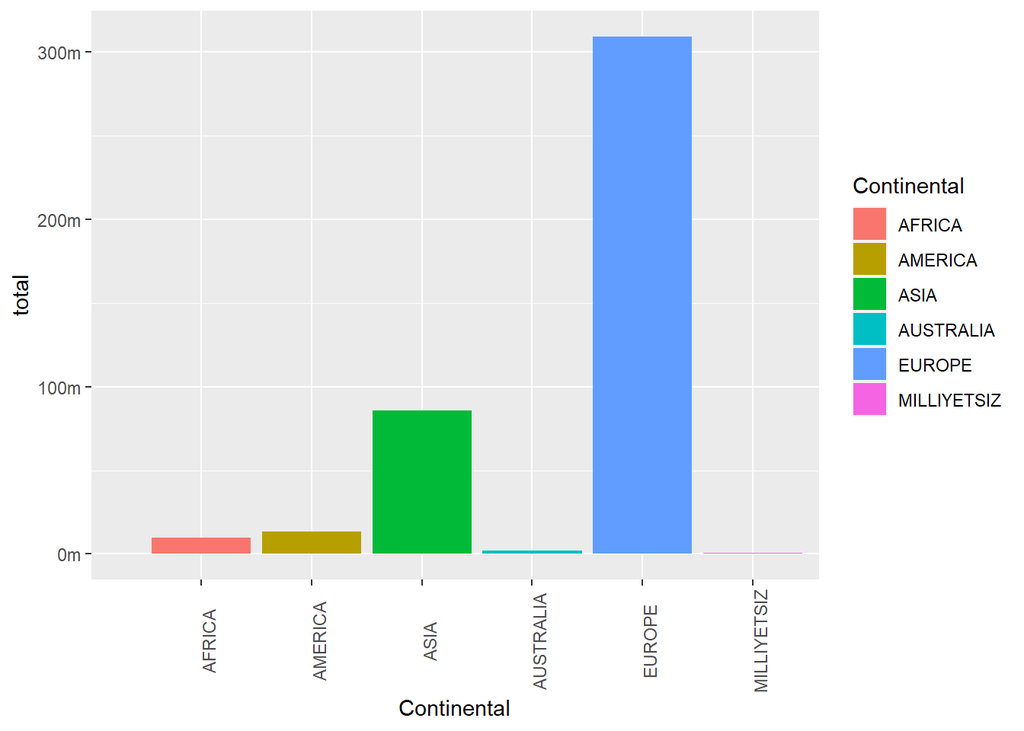

```r
tbn_cont <- tbn_melt %>% mutate(Year = format(tbn_melt$Tarih, "%Y")) %>%
  group_by(Year, Continental) %>% summarise(total = sum(value))

ggplot(tbn_cont, aes(x = Continental, y = total, fill =Continental)) + geom_bar(stat="identity",aes(fill= Continental)) +
theme(axis.text.x = element_text(angle = 90)) +
  expand_limits( x = c(0,NA), y = c(0,NA)) +
  scale_y_continuous(labels = function(l) {
    paste0(round(l/1e6,1),"m")
  })
```

The European continent appears to have the largest percentage.

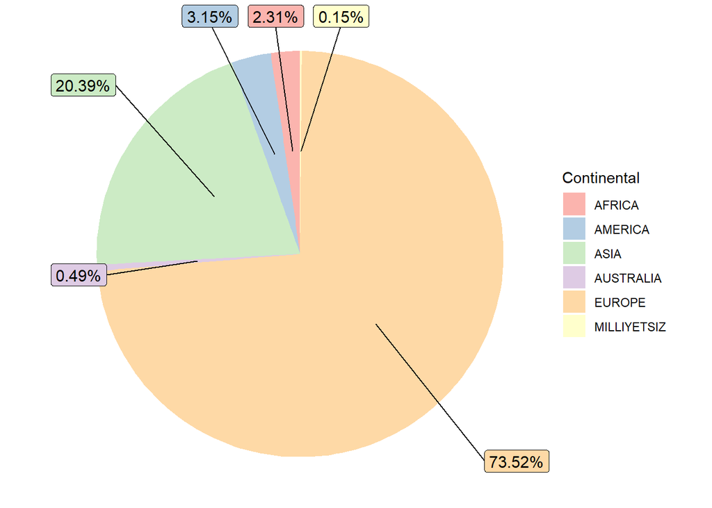

```r
tbn_pie <- tbn_melt  %>% group_by(Continental) %>% summarise(total = sum(value)) %>%
  mutate(fraction = total *100 / sum(total)) %>%
  mutate(perc = round(fraction,2))


df2 <- tbn_pie %>%
  mutate(
    cs = rev(cumsum(rev(perc))),
    pos =perc/2 + lead(cs, 1),
    pos = if_else(is.na(pos), perc/2, pos))



ggplot(tbn_pie, aes(x = "", y = perc, fill = Continental)) +
  geom_bar(width = 1, stat = "identity") +
  geom_label_repel(aes(y = pos, label = paste0(perc, "%")), data = df2, size=4, show.legend = F, nudge_x = 1) +
  guides(fill = guide_legend(title = "Continental")) +
  scale_fill_brewer(palette = "Pastel1") +
  coord_polar(theta = "y", start = 0) +
  theme_void()
```

```r
tbn_buble <- tbn_melt %>% mutate(Year = format(tbn_melt$Tarih, "%Y")) %>%
  group_by(Year,Continental, Country) %>% summarise(total = sum(value))
```

In the European region, tourists come mostly from Germany and Russia. The high number of Turks living in Germany may be one of the most important effects of this. There appears to be a decrease in the number of visitors from Russia in 2016. It can be understood from the graph that events such as terrorist activities, coup attempts, and shooting Russian warplane in our country in 2015 and 2016 caused a significant decrease.

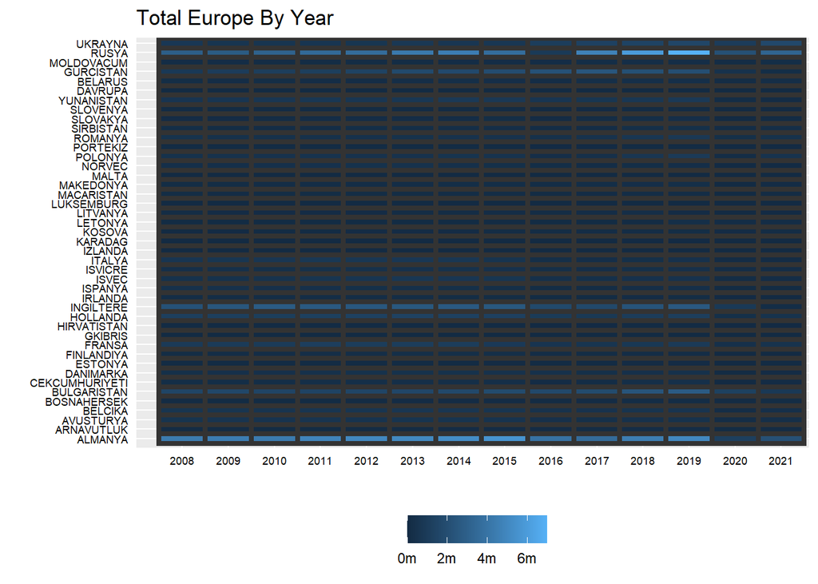

```r
ggplot(tbn_buble %>% filter(Continental == "EUROPE"), aes(Year, Country, fill = total)) +
  geom_tile(colour="gray20", size=1.5, stat="identity") +
  scale_fill_viridis(option="A") +
  xlab("") +
  ylab("") +
  ggtitle("Total Europe By Year") +
  theme(
    axis.line = element_blank(),
    axis.ticks = element_blank(),
    axis.text = element_text(color="black", size=rel(0.6)),
    axis.text.y  = element_text(hjust=1),
    legend.position = "bottom",
    legend.title=element_blank()
    ) +
  expand_limits( x = c(0,NA), y = c(0,NA)) +
  scale_fill_continuous(labels = function(l) {
    paste0(round(l/1e6,1),"m")
  })
```

Visitors from the Asian region are mostly received from Iran. Due to the political events in Syria, there was a large number of immigrants to Turkey in 2010 and 2011. In the following years, we see that this number of migration is decreasing.

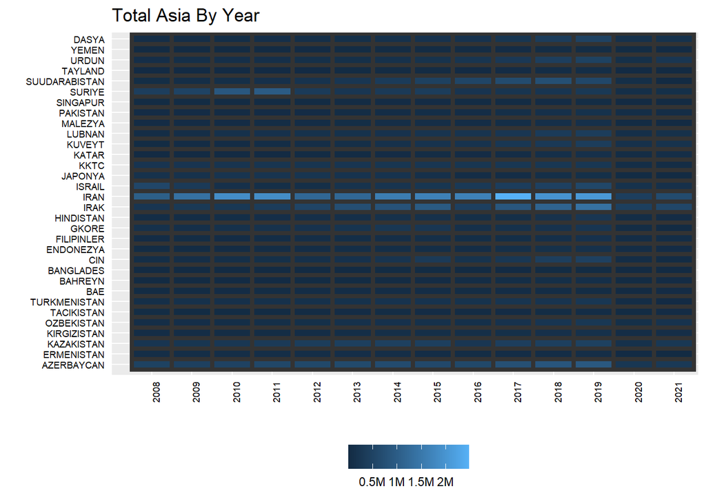

```r
ggplot(tbn_buble %>% filter(Continental == "ASIA"), aes(Year, Country, fill = total)) +
  geom_tile(colour="gray20", size=1.5, stat="identity") +
  scale_fill_viridis(option="A") +
  xlab("") +
  ylab("") +
  ggtitle("Total Asia By Year") +
  theme(
    axis.line = element_blank(),
    axis.ticks = element_blank(),
    axis.text = element_text(color="black", size=rel(0.6)),
    axis.text.y  = element_text(hjust=1),
    legend.position = "bottom",
    legend.title=element_blank()
  ) +
  theme(axis.text.x = element_text(angle = 90)) +
  expand_limits( x = c(0,NA), y = c(0,NA)) +
  scale_fill_continuous(labels = function(l) {
    paste0(round(l/1e6,1),"M")
  })
```

We see that the number of incoming tourists has increased until 2016. After the coup attempt in Turkey in 2015, we see that there has been a decrease and cannot reach the previous years levels.

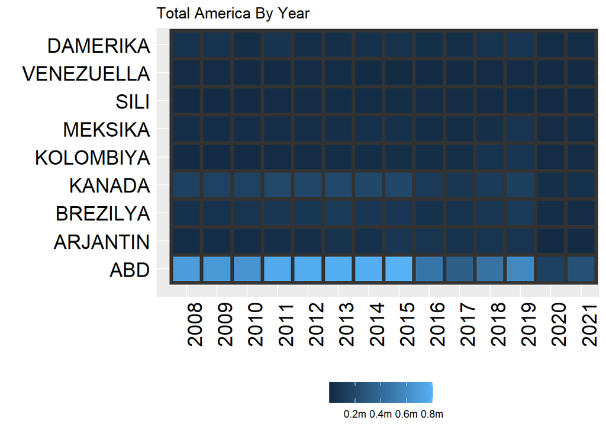

```r
ggplot(tbn_buble %>% filter(Continental == "AMERICA"), aes(Year, Country, fill = total)) +
  geom_tile(colour="gray20", size=1.5, stat="identity") +
  scale_fill_viridis(option="A") +
  xlab("") +
  ylab("") +
  ggtitle("Total America By Year") +
  theme(
    axis.line = element_blank(),
    axis.ticks = element_blank(),
    axis.text = element_text(color="black", size=rel(1.5)),
    axis.text.y  = element_text(hjust=1),
    legend.position = "bottom",
    legend.title=element_blank()
  ) +
  theme(axis.text.x = element_text(angle = 90)) +
  expand_limits( x = c(0,NA), y = c(0,NA)) +
  scale_fill_continuous(labels = function(l) {
    paste0(round(l/1e6,1),"m")
  })
```

Due to the Arab Spring events that started in the North African region in 2010, the number of visitors increased in the following years.

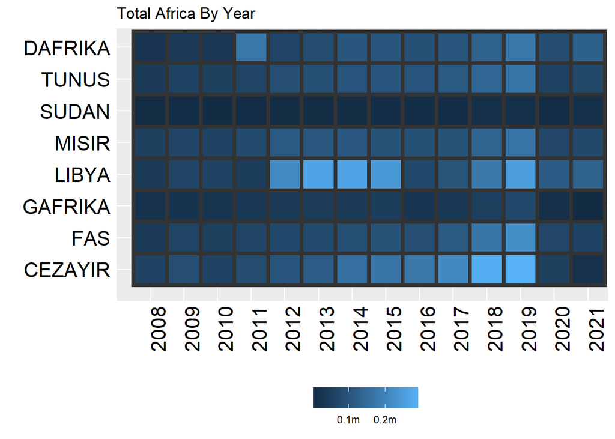

```r
ggplot(tbn_buble %>% filter(Continental == "AFRICA"), aes(Year, Country, fill = total)) +
  geom_tile(colour="gray20", size=1.5, stat="identity") +
  scale_fill_viridis(option="A") +
  xlab("") +
  ylab("") +
  ggtitle("Total Africa By Year") +
  theme(
   axis.line = element_blank(),
    axis.ticks = element_blank(),
    axis.text = element_text(color="black", size=rel(1.5)),
    axis.text.y  = element_text(hjust=1),
    legend.position = "bottom",
    legend.title=element_blank()
  ) +
  theme(axis.text.x = element_text(angle = 90)) +
  expand_limits( x = c(0,NA), y = c(0,NA)) +
  scale_fill_continuous(labels = function(l) {
    paste0(round(l/1e6,1),"m")
  })
```

The reason for the decrease in the number of visitors in this region after 2015 can be interpreted as the coup attempt in Turkey.

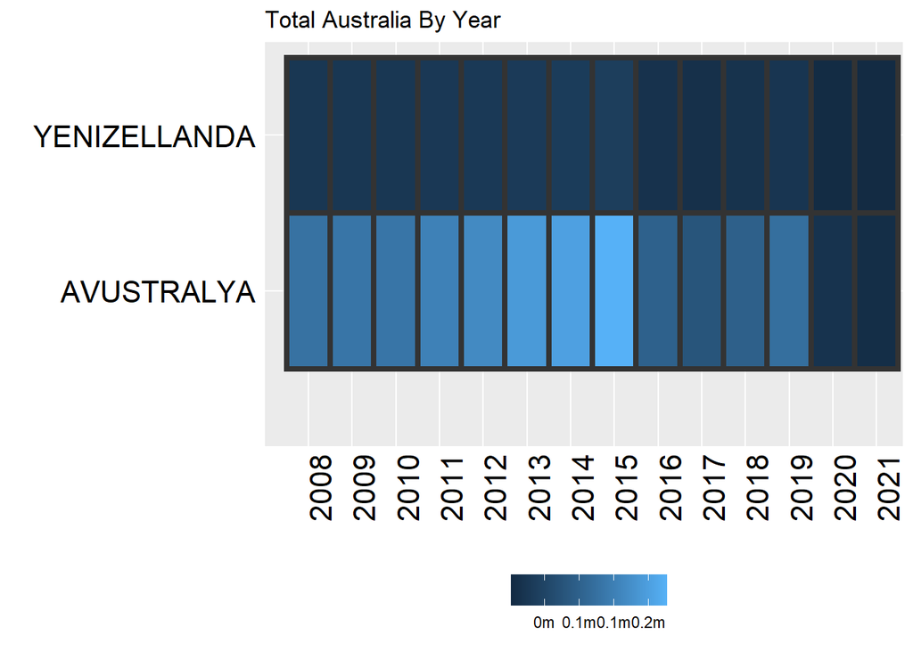

```r
ggplot(tbn_buble %>% filter(Continental == "AUSTRALIA")%>% top_n(5), aes(Year, Country, fill = total)) +
  geom_tile(colour="gray20", size=1.5, stat="identity") +
  scale_fill_viridis(option="A") +
  xlab("") +
  ylab("") +
  ggtitle("Total Australia By Year") +
  theme(
    axis.line = element_blank(),
    axis.ticks = element_blank(),
    axis.text = element_text(color="black", size=rel(1.5)),
    axis.text.y  = element_text(hjust=1),
    legend.position = "bottom",
    legend.title=element_blank()
  ) +
  theme(axis.text.x = element_text(angle = 90)) +
  expand_limits( x = c(0,NA), y = c(0,NA)) +
  scale_fill_continuous(labels = function(l) {
    paste0(round(l/1e6,1),"m")
  })
```

### *Distribution of Tourists by Border Gates*

Dataset showing the distribution of foreign tourists visited Turkey between 2008 and 2021 according to the customs gates.

```r
library(treemap)
library(treemapify)

df <- read_rds("https://raw.githubusercontent.com/pjournal/mef05g-r-u-mine/gh-pages/files/distribution_border.rds")

df$TOPLAM <- NULL

df1 <- df[, 1:2]
df1$ADANA <- NULL
df2 <- apply(df[,2:82], FUN = decomma, MARGIN = 2)
db = cbind(df1,df2)

str(db)
```

```
## 'data.frame':    165 obs. of  82 variables:
##  $ Tarih     : chr  "2008/01" "2008/02" "2008/03" "2008/04" ...
##  $ ADANA     : num  5996 6169 5496 5991 10403 ...
##  $ ADIYAMAN  : num  0 0 0 0 0 0 0 0 0 0 ...
##  $ AFYON     : num  0 0 0 0 0 0 0 0 0 0 ...
##  $ AGRI      : num  9642 14390 46563 34457 47046 ...
##  $ AMASYA    : num  0 0 0 0 0 0 0 0 0 0 ...
##  $ ANKARA    : num  16920 19524 23033 24198 29714 ...
##  $ ANTALYA   : num  121458 152011 291077 473912 1037876 ...
##  $ ARTVIN    : num  43235 42846 50674 57445 69285 ...
##  $ AYDIN     : num  80 83 8139 25818 70702 ...
##  $ BALIKESIR : num  465 296 506 852 369 ...
##  $ BILECIK   : num  0 0 0 0 0 0 0 0 0 0 ...
##  $ BINGOL    : num  0 0 0 0 0 0 0 0 0 0 ...
##  $ BITLIS    : num  0 0 0 0 0 0 0 0 0 0 ...
```

[output cut: 68 more lines]

```r
colSums(is.na(db))
```

```
##      Tarih      ADANA   ADIYAMAN      AFYON       AGRI     AMASYA     ANKARA
##          0          0          0          0          0          0          0
##    ANTALYA     ARTVIN      AYDIN  BALIKESIR    BILECIK     BINGOL     BITLIS
##          0          0          0          0          0          0          0
##       BOLU     BURDUR      BURSA  CANAKKALE    CANKIRI      CORUM    DENIZLI
##          0          0          0          0          0          0          0
## DIYARBAKIR     EDIRNE     ELAZIG   ERZINCAN    ERZURUM  ESKISEHIR  GAZIANTEP
##          0          0          0          0          0          0          0
##    GIRESUN  GUMUSHANE    HAKKARI      HATAY    ISPARTA     MERSIN   ISTANBUL
##          0          0          0          0          0          0          0
##      IZMIR       KARS  KASTAMONU    KAYSERI KIRKLARELI   KIRSEHIR    KOCAELI
##          0          0          0          0          0          1          0
##      KONYA    KUTAHYA    MALATYA     MANISA      MARAS     MARDIN      MUGLA
##          0          0          0          0          0          0          0
##        MUS   NEVSEHIR      NIGDE       ORDU       RIZE    SAKARYA     SAMSUN
##          0          0          1          0          0          0          0
##      SIIRT      SINOP      SIVAS   TEKIRDAG      TOKAT    TRABZON    TUNCELI
##          0          0          0          0          0          0          0
##       URFA       USAK        VAN     YOZGAT  ZONGULDAK    AKSARAY    BAYBURT
##          0          1          0          0          0          0          0
##    KARAMAN  KIRIKKALE     BATMAN     SIRNAK     BARTIN    ARDAHAN      IGDIR
##          0          0          1          0          0          0          0
##     YALOVA    KARABUK      KILIS   OSMANIYE      DUZCE
##          0          1          0          0          0
```

```r
db$Tarih <- paste0(db$Tarih,"/01")

str(db$Tarih)
```

```
##  chr [1:165] "2008/01/01" "2008/02/01" "2008/03/01" "2008/04/01" ...
```

```r
db$Tarih <- as.Date(db$Tarih, format = "%Y/%m/%d")
str(db$Tarih)
```

```
##  Date[1:165], format: "2008-01-01" "2008-02-01" "2008-03-01" "2008-04-01" "2008-05-01" ...
```

```r
str(db)
```

```
## 'data.frame':    165 obs. of  82 variables:
##  $ Tarih     : Date, format: "2008-01-01" "2008-02-01" ...
##  $ ADANA     : num  5996 6169 5496 5991 10403 ...
##  $ ADIYAMAN  : num  0 0 0 0 0 0 0 0 0 0 ...
##  $ AFYON     : num  0 0 0 0 0 0 0 0 0 0 ...
##  $ AGRI      : num  9642 14390 46563 34457 47046 ...
##  $ AMASYA    : num  0 0 0 0 0 0 0 0 0 0 ...
##  $ ANKARA    : num  16920 19524 23033 24198 29714 ...
##  $ ANTALYA   : num  121458 152011 291077 473912 1037876 ...
##  $ ARTVIN    : num  43235 42846 50674 57445 69285 ...
##  $ AYDIN     : num  80 83 8139 25818 70702 ...
##  $ BALIKESIR : num  465 296 506 852 369 ...
##  $ BILECIK   : num  0 0 0 0 0 0 0 0 0 0 ...
##  $ BINGOL    : num  0 0 0 0 0 0 0 0 0 0 ...
##  $ BITLIS    : num  0 0 0 0 0 0 0 0 0 0 ...
```

[output cut: 68 more lines]

```r
db_melt <- melt(db, id.vars = "Tarih")
str(db)
```

```
## 'data.frame':    165 obs. of  82 variables:
##  $ Tarih     : Date, format: "2008-01-01" "2008-02-01" ...
##  $ ADANA     : num  5996 6169 5496 5991 10403 ...
##  $ ADIYAMAN  : num  0 0 0 0 0 0 0 0 0 0 ...
##  $ AFYON     : num  0 0 0 0 0 0 0 0 0 0 ...
##  $ AGRI      : num  9642 14390 46563 34457 47046 ...
##  $ AMASYA    : num  0 0 0 0 0 0 0 0 0 0 ...
##  $ ANKARA    : num  16920 19524 23033 24198 29714 ...
##  $ ANTALYA   : num  121458 152011 291077 473912 1037876 ...
##  $ ARTVIN    : num  43235 42846 50674 57445 69285 ...
##  $ AYDIN     : num  80 83 8139 25818 70702 ...
##  $ BALIKESIR : num  465 296 506 852 369 ...
##  $ BILECIK   : num  0 0 0 0 0 0 0 0 0 0 ...
##  $ BINGOL    : num  0 0 0 0 0 0 0 0 0 0 ...
##  $ BITLIS    : num  0 0 0 0 0 0 0 0 0 0 ...
```

[output cut: 68 more lines]

```r
colSums(is.na(db_melt))
```

```
##    Tarih variable    value
##        0        0        5
```

```r
names(db_melt)[names(db_melt) == "variable"] <- "City"

head(df)
```

|  | Tarih | ADANA | ADIYAMAN | AFYON | AGRI | AMASYA | ANKARA | ANTALYA | ARTVIN | AYDIN | BALIKESIR | BILECIK | BINGOL | BITLIS | BOLU | BURDUR | BURSA | CANAKKALE | CANKIRI | CORUM | DENIZLI | DIYARBAKIR | EDIRNE | ELAZIG | ERZINCAN | ERZURUM | ESKISEHIR | GAZIANTEP | GIRESUN | … |
| --- | --- | --- | --- | --- | --- | --- | --- | --- | --- | --- | --- | --- | --- | --- | --- | --- | --- | --- | --- | --- | --- | --- | --- | --- | --- | --- | --- | --- | --- | --- |
| 1 | 2008/01 | 5,996 | 0 | 0 | 9,642 | 0 | 16,920 | 121,458 | 43,235 | 80 | 465 | 0 | 0 | 0 | 0 | 0 | 2,383 | 28 | 0 | 0 | 4 | 1 | 100,303 | 0 | 0 | 2,356 | 0 | 2,080 | 52 | … |
| 2 | 2008/02 | 6,169 | 0 | 0 | 14,390 | 0 | 19,524 | 152,011 | 42,846 | 83 | 296 | 0 | 0 | 0 | 0 | 0 | 63 | 114 | 0 | 0 | 0 | 0 | 108,488 | 0 | 0 | 2,013 | 0 | 2,378 | 69 | … |
| 3 | 2008/03 | 5,496 | 0 | 0 | 46,563 | 0 | 23,033 | 291,077 | 50,674 | 8,139 | 506 | 0 | 0 | 0 | 0 | 0 | 48 | 570 | 0 | 0 | 0 | 0 | 138,234 | 0 | 0 | 948 | 0 | 3,726 | 92 | … |
| 4 | 2008/04 | 5,991 | 0 | 0 | 34,457 | 0 | 24,198 | 473,912 | 57,445 | 25,818 | 852 | 0 | 0 | 0 | 0 | 0 | 100 | 882 | 0 | 0 | 0 | 1 | 166,926 | 0 | 0 | 29 | 0 | 4,431 | 168 | … |
| 5 | 2008/05 | 10,403 | 0 | 0 | 47,046 | 0 | 29,714 | 1,037,876 | 69,285 | 70,702 | 369 | 0 | 0 | 0 | 0 | 0 | 57 | 75 | 0 | 0 | 0 | 0 | 173,116 | 0 | 0 | 325 | 187 | 6,236 | 93 | … |
| 6 | 2008/06 | 11,868 | 0 | 0 | 56,354 | 0 | 52,811 | 1,282,239 | 67,264 | 75,438 | 2,148 | 0 | 0 | 0 | 0 | 0 | 90 | 1,772 | 0 | 0 | 0 | 0 | 305,595 | 0 | 0 | 496 | 234 | 7,069 | 54 | … |

This treemap chart shows that top 10 cities with the most tourists.

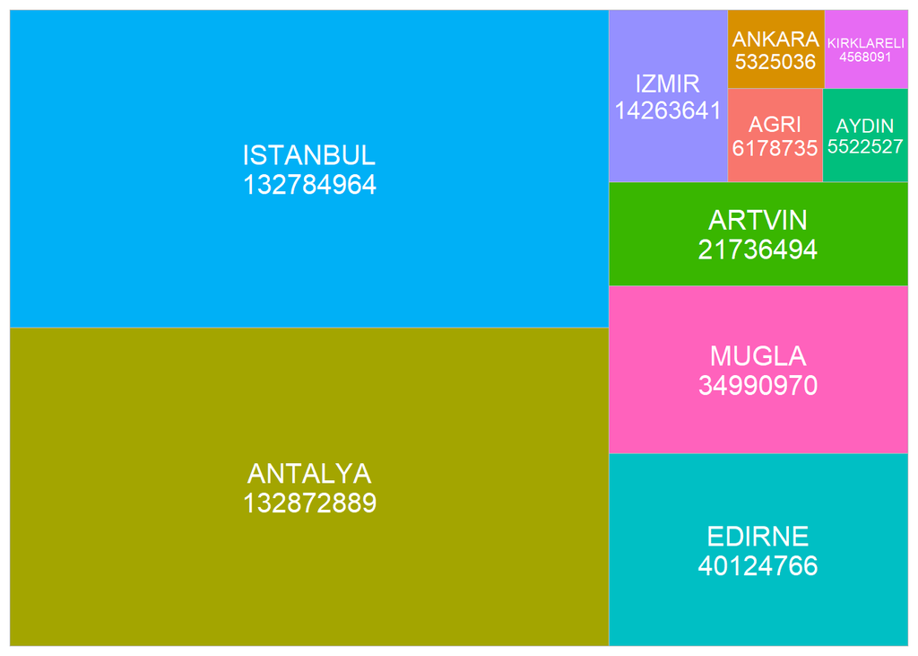

```r
db_top10 <- db_melt %>% na.omit(db_melt) %>% group_by(City) %>%
  summarise(total = sum(value)) %>%
  slice_max(order_by = total, n = 10)

ggplot(db_top10, aes(area = total, fill = City,
               label = paste(City, total, sep = "\n"))) +
  geom_treemap() +
  geom_treemap_text(colour = "white",
                    place = "centre",
                    size = 15) +
  theme(legend.position = "none")
```

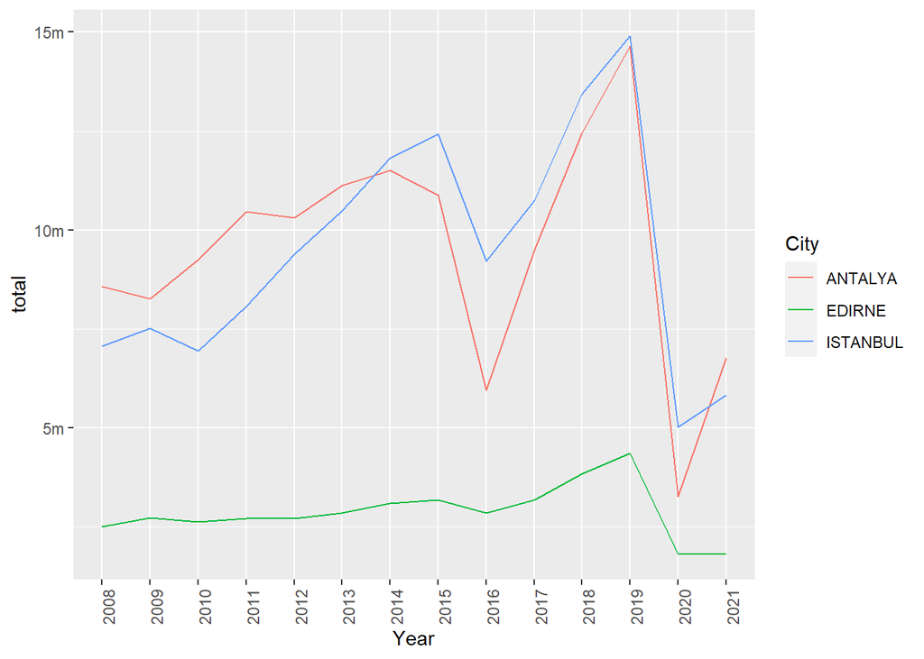

```r
db_line <- db_melt %>% mutate(Year = format(db_melt$Tarih, "%Y")) %>%
  group_by(Year, City) %>%
  filter(City %in% c("ANTALYA", "ISTANBUL", "EDIRNE"))  %>%
  summarise(total = sum(value))


ggplot(db_line, aes(x=Year, y=total, group=City, color=City)) +
  geom_line() + theme(axis.text.x = element_text(angle = 90)) +
  scale_y_continuous(labels = function(l) {
    paste0(round(l/1e6,1),"m")
  })
```

In this box plot, we can clearly see the outlier values and years. While the number of visits was higher in 2018 and 2019 compared to other years, we see that dramatically decreasing in 2020 with the effect of the pandemic. With the development of the vaccine in 2021, we see that the effect of the pandemic has decreased and it has started to increase again, but it still has not reached the previous levels.

```r
db_top3 <- db_melt %>%  mutate(Year = format(db_melt$Tarih, "%Y")) %>% na.omit(db_melt) %>%
  group_by(Year, City) %>%
  filter(City %in% c("ANTALYA", "ISTANBUL", "EDIRNE")) %>%
  summarise(total = sum(value)) %>%
  slice_max(order_by = total, n = 10)
```

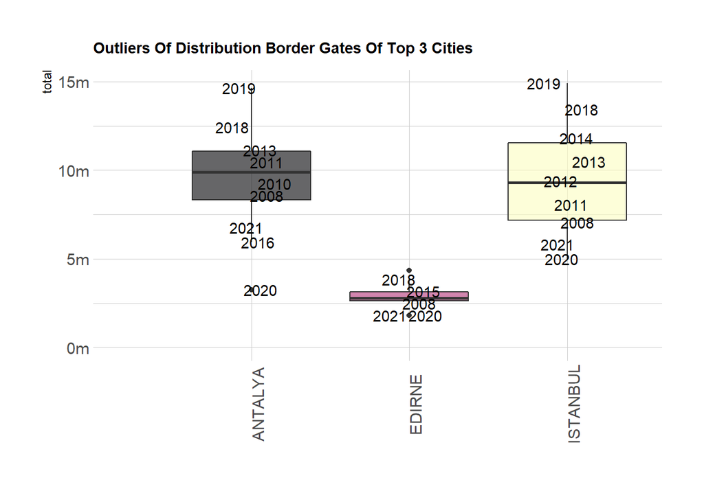

```r
ggplot( db_top3, aes(x=City, y=total, label = Year, fill =City )) +
  geom_boxplot() +
  geom_text(check_overlap = TRUE,
            position=position_jitter(width=0.15))+
  scale_fill_viridis(discrete = TRUE, alpha=0.6, option="A") +
  theme_ipsum() +
  theme(
    legend.position="none",
    plot.title = element_text(size=11)
  ) +
  ggtitle("Outliers Of Distribution Border Gates Of Top 3 Cities") +
  xlab("") +
  theme(axis.text.x = element_text(angle = 90)) +
  expand_limits( x = c(0,NA), y = c(0,NA)) +
  scale_y_continuous(labels = function(l) {
    paste0(round(l/1e6,1),"m")
  })
```

### *Travel Incomes and Expenses*

Dataset showing Turkey’s tourism revenues and expenses between 2008 and 2021.

```r
trv <- read_rds("https://raw.githubusercontent.com/pjournal/mef05g-r-u-mine/gh-pages/files/travel_incomes_expenses.rds")

trv <- trv[-c(166,167), ]
trv1 <- trv[, 1:2]
trv1$K1 <- NULL
trv2 <- apply(trv[,2:14], FUN = decomma, MARGIN = 2)
trv_raw = cbind(trv1,trv2)

str(trv_raw)
```

```
## 'data.frame':    165 obs. of  14 variables:
##  $ Tarih: chr  "2008-01-01" "2008-02-01" "2008-03-01" "2008-04-01" ...
##  $ K1   : num  917 827 1128 1128 1837 ...
##  $ K2   : num  5 2 3 1 3 4 5 5 2 4 ...
##  $ K3   : num  1172736 1073986 1478744 1677867 2769178 ...
##  $ K4   : num  782 770 762 672 663 667 786 800 799 764 ...
##  $ K5   : num  642 597 851 879 1592 ...
##  $ K6   : num  919539 858751 1221568 1411495 2509997 ...
##  $ K7   : num  698 695 697 623 634 641 715 720 723 708 ...
##  $ K8   : num  270 228 273 247 241 ...
##  $ K9   : num  253197 215235 257176 266372 259181 ...
##  $ K10  : num  1067 1062 1063 928 931 ...
##  $ K11  : num  275 255 278 300 324 394 334 265 196 414 ...
##  $ K12  : num  352491 338170 374133 427658 461661 ...
##  $ K13  : num  781 755 743 703 701 695 764 759 746 924 ...
```

```r
colSums(is.na(trv_raw))
```

```
## Tarih    K1    K2    K3    K4    K5    K6    K7    K8    K9   K10   K11   K12
##     0     2     3     3     3     3     3     3     3     3     3     2     3
##   K13
##     3
```

```r
trv_raw$Tarih <- as.Date(trv_raw$Tarih, format = "%Y-%m-%d")
str(trv_raw$Tarih)
```

```
##  Date[1:165], format: "2008-01-01" "2008-02-01" "2008-03-01" "2008-04-01" "2008-05-01" ...
```

```r
trv_melt <- melt(trv_raw, id.vars = "Tarih")
str(trv_melt)
```

```
## 'data.frame':    2145 obs. of  3 variables:
##  $ Tarih   : Date, format: "2008-01-01" "2008-02-01" ...
##  $ variable: Factor w/ 13 levels "K1","K2","K3",..: 1 1 1 1 1 1 1 1 1 1 ...
##  $ value   : num  917 827 1128 1128 1837 ...
```

```r
colSums(is.na(trv_melt))
```

```
##    Tarih variable    value
##        0        0       37
```

The graph values depend on the criteria below, according to which a time-dependent plot was created. Due to the value loss of Turkish Lira since 2008, per capita expenditures have decreased in dollars too.

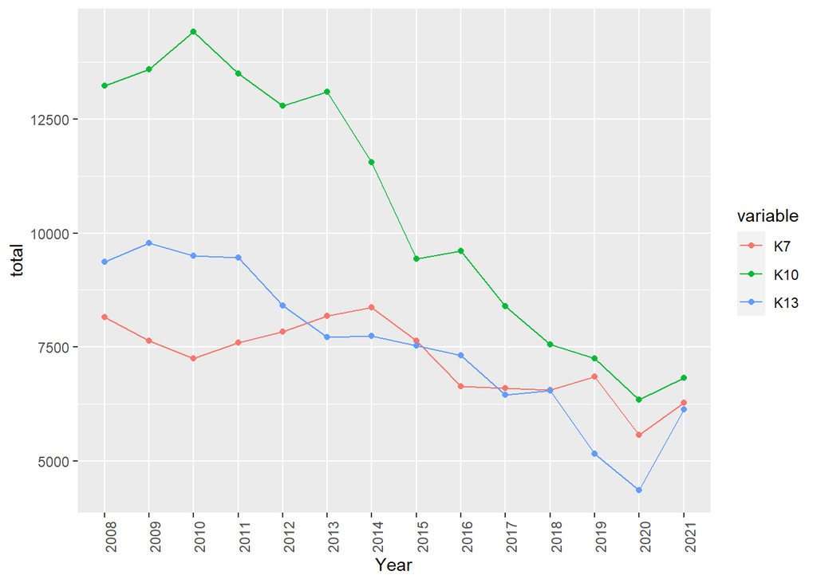

```r
trv_k13 <- trv_melt %>% mutate(Year = format(trv_melt$Tarih, "%Y")) %>%
            filter(trv_melt$variable %in% c("K13","K10", "K7")) %>%
            group_by(Year, variable) %>%
            summarise(total = sum(value,na.rm = TRUE))

ggplot(trv_k13, aes(x=Year, y=total, group=variable, color=variable)) +
  geom_line() + theme(axis.text.x = element_text(angle = 90)) + geom_point()
```